# An Agile Widget Engine for Real-time, Dynamic Visualizations: the *switchboard* package for *R* [BETA]

[Marc J. Lajeunesse](http://lajeunesse.myweb.usf.edu/)

University of South Florida, October 7th 2021 (vignette v. 0.1 for switchboard v.0.1)

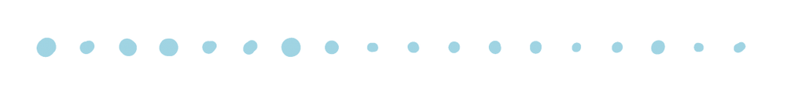

# Purpose of the **switchboard** package

The **switchboard** package for [R](http://www.r-project.org/) is an agile widget engine for creating dynamic, real-time dashboards for iterative simulations (e.g., for/while loops). It contains a growing, unsorted collection of visualization widgets rendered in a Tcl/Tk GUI–these include progress bars, counters, eavesdroppers, injectors, switches, and sliders. Below is a brief tutorial to get started on creating your own dashboards.

Updates to this vignette will be posted on our [research webpage at USF](http://lajeunesse.myweb.usf.edu/).

### How to cite? TBA, but for this beta version maybe:

Lajeunesse, M.J. (2021) Creating dynamic, real-time dashboards with the **switchboard** package for *R*. R package, v. 0.1.

### Report a bug? Have comments or suggestions?

Please email me any bugs, comments, or suggestions and I’ll try to include them in future releases: lajeunesse@usf.edu. Also try to include **switchboard** in the subject heading of your email. Finally, I’m open to almost anything, but expect a lag before I respond and/or new additions are added.

### Video tutorials on Youtube (click on switchboard hex to watch)

[figure not shown]

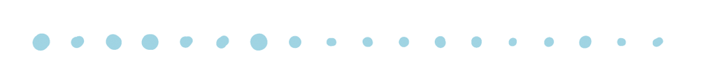

# Quick Monte Carlo simulation

Here is how you would script a small Monte Carlo simulation exploring the effects of sample size on linear regression estimation:

[figure not shown]

```r
library(switchboard)
library(MASS)

pop_rho <- 0
pop_X <- 0
pop_Y <- 0
pop_forget <- 400 #milliseconds
ctrl_regression <- FALSE
ctrl_N <- FALSE

for(i in 1:1e5) {

  cov_XY <- matrix(c(1, pop_rho, pop_rho, 1), nrow = 2, ncol = 2)
  sample_XY <- MASS::mvrnorm(1, mu = c(pop_X, pop_Y), Sigma = cov_XY)

  switchboard() %>%
    caption(c("Monte Carlo Simulation",
              "Slide sample size to see how it impacts regression estimation.
              Few samples results in poor estimation."),
            placeOnGrid = c(1,1), size = 2) %>%
    control_switch_pair(c("ctrl_regression", "ctrl_N"),
                        label = c("regression line", "plot N"), placeOnGrid = c(1,3)) %>%
    control_slider_pair(c("pop_rho","pop_forget"),
                        minimum = c(-1, 4), maximum = c(1, 3000),
                        label = c("correlation", "sample size"),
                        placeOnGrid = c(2,3)) %>%
    injector_2D(c(sample_XY[1], sample_XY[2]),
                inject = c("pop_X", "pop_Y"),
                minimum = c(-5,-5), maximum = c(5,5),
                plotRegression = ctrl_regression, plotSampleSize = ctrl_N, size = 2,
                forget = pop_forget, placeOnGrid = c(1,4), switch = TRUE)

}
switchboard_close()
```